# Survivability analysis

Ignat Sonets

3/5/2021

Hello! Today we perform survival analysis.

# Tasks

1. Do EDA
2. Plot Kaplan-Meier curve plots
3. Find groups which are different
4. Find factors that have impact on survival

# 0. Install & load packages

# 1. EDA

Loading data:

```r
surv_data <- ovarian
```

Short description of variables:

*futime*: survival or censoring time

*fustat*: censoring status

*age*: in years

*resid.ds*: residual disease present (1=no,2=yes)

*rx*: treatment group

*ecog.ps*: ECOG performance status (1 is better, see reference http://www.npcrc.org/files/news/ECOG_performance_status.pdf)

Descriptive stats:

```r
str(surv_data)
```

```
## 'data.frame':    26 obs. of  6 variables:
##  $ futime  : num  59 115 156 421 431 448 464 475 477 563 ...
##  $ fustat  : num  1 1 1 0 1 0 1 1 0 1 ...
##  $ age     : num  72.3 74.5 66.5 53.4 50.3 ...
##  $ resid.ds: num  2 2 2 2 2 1 2 2 2 1 ...
##  $ rx      : num  1 1 1 2 1 1 2 2 1 2 ...
##  $ ecog.ps : num  1 1 2 1 1 2 2 2 1 2 ...
```

```r
describe(surv_data)
```

```
## surv_data
##
##  6  Variables      26  Observations
## --------------------------------------------------------------------------------
## futime
##        n  missing distinct     Info     Mean      Gmd      .05      .10
##       26        0       26        1    599.5    390.3    125.2    212.0
##      .25      .50      .75      .90      .95
##    368.0    476.0    794.8   1117.5   1186.8
##
## lowest :   59  115  156  268  329, highest: 1040 1106 1129 1206 1227
## --------------------------------------------------------------------------------
## fustat
##        n  missing distinct     Info      Sum     Mean      Gmd
##       26        0        2    0.747       12   0.4615   0.5169
##
## --------------------------------------------------------------------------------
## age
##        n  missing distinct     Info     Mean      Gmd      .05      .10
##       26        0       26        1    56.17    11.64    40.23    43.13
##      .25      .50      .75      .90      .95
##    50.17    56.85    62.38    69.40    73.95
##
## lowest : 38.8932 39.2712 43.1233 43.1370 44.2055
## highest: 64.4247 66.4658 72.3315 74.4932 74.5041
## --------------------------------------------------------------------------------
## resid.ds
##        n  missing distinct     Info     Mean      Gmd
##       26        0        2    0.733    1.577   0.5077
##
## Value          1     2
## Frequency     11    15
## Proportion 0.423 0.577
## --------------------------------------------------------------------------------
## rx
##        n  missing distinct     Info     Mean      Gmd
##       26        0        2    0.751      1.5     0.52
##
## Value        1   2
## Frequency   13  13
## Proportion 0.5 0.5
## --------------------------------------------------------------------------------
## ecog.ps
##        n  missing distinct     Info     Mean      Gmd
##       26        0        2    0.747    1.462   0.5169
##
## Value          1     2
## Frequency     14    12
## Proportion 0.538 0.462
## --------------------------------------------------------------------------------
```

```r
summary(surv_data)
```

```
##      futime           fustat            age           resid.ds
##  Min.   :  59.0   Min.   :0.0000   Min.   :38.89   Min.   :1.000
##  1st Qu.: 368.0   1st Qu.:0.0000   1st Qu.:50.17   1st Qu.:1.000
##  Median : 476.0   Median :0.0000   Median :56.85   Median :2.000
##  Mean   : 599.5   Mean   :0.4615   Mean   :56.17   Mean   :1.577
##  3rd Qu.: 794.8   3rd Qu.:1.0000   3rd Qu.:62.38   3rd Qu.:2.000
##  Max.   :1227.0   Max.   :1.0000   Max.   :74.50   Max.   :2.000
##        rx         ecog.ps
##  Min.   :1.0   Min.   :1.000
##  1st Qu.:1.0   1st Qu.:1.000
##  Median :1.5   Median :1.000
##  Mean   :1.5   Mean   :1.462
##  3rd Qu.:2.0   3rd Qu.:2.000
##  Max.   :2.0   Max.   :2.000
```

Checking for NAs:

```r
complete.cases(surv_data)
```

```
##  [1] TRUE TRUE TRUE TRUE TRUE TRUE TRUE TRUE TRUE TRUE TRUE TRUE TRUE TRUE TRUE
## [16] TRUE TRUE TRUE TRUE TRUE TRUE TRUE TRUE TRUE TRUE TRUE
```

No NAs found. Good.

Histograms for numeric data:

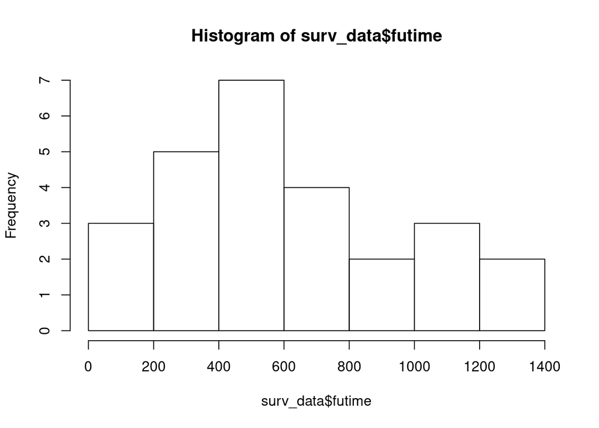

```r
hist(surv_data$futime)
```

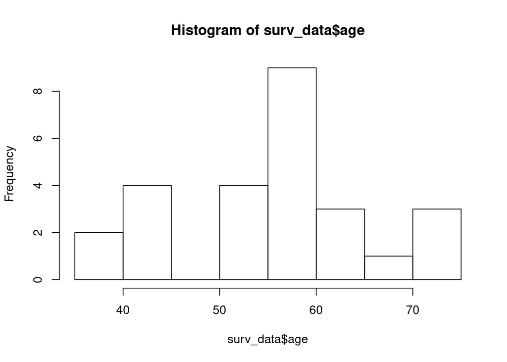

```r
hist(surv_data$age)
```

Frequency stats for factor vairables:

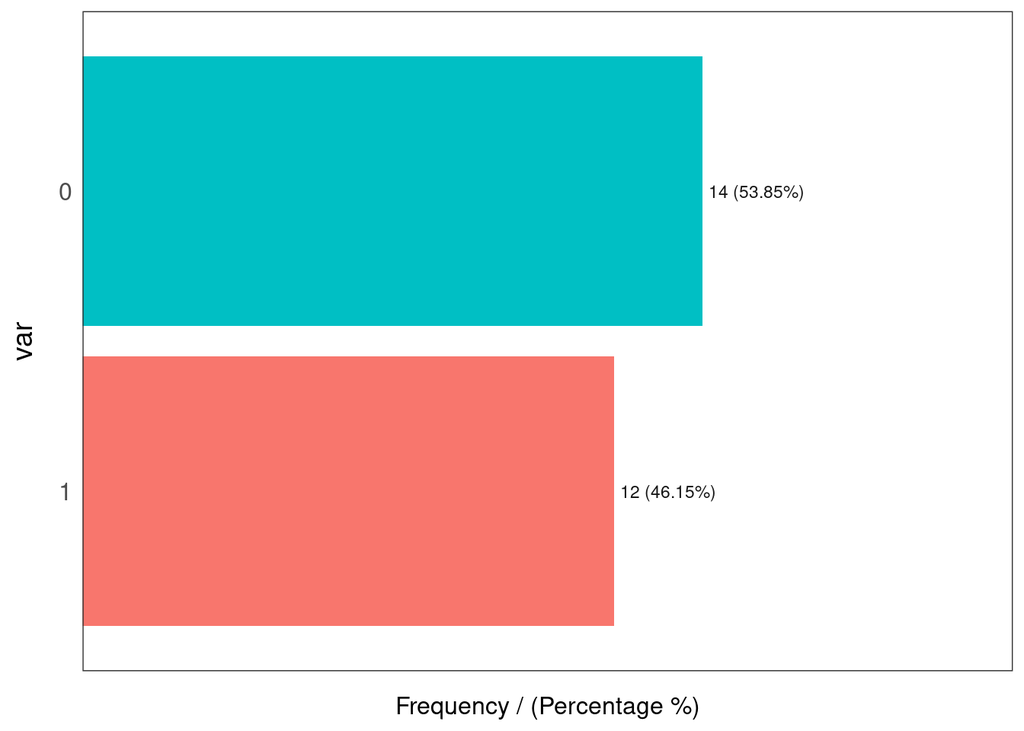

```
##   var frequency percentage cumulative_perc
## 1   0        14      53.85           53.85
## 2   1        12      46.15          100.00
```

```r
freq(surv_data$fustat)
```

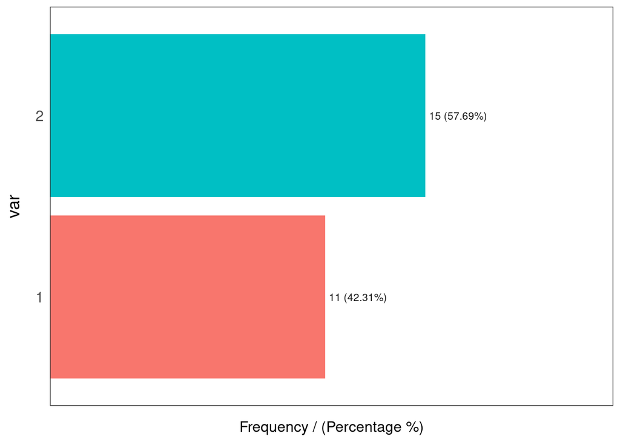

```
##   var frequency percentage cumulative_perc
## 1   2        15      57.69           57.69
## 2   1        11      42.31          100.00
```

```r
freq(surv_data$resid.ds)
```

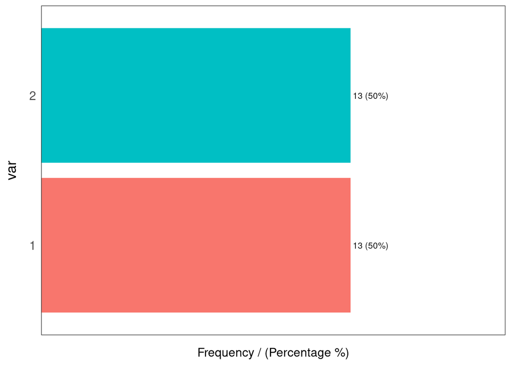

```
##   var frequency percentage cumulative_perc
## 1   1        13         50              50
## 2   2        13         50             100
```

```r
freq(surv_data$rx)
```

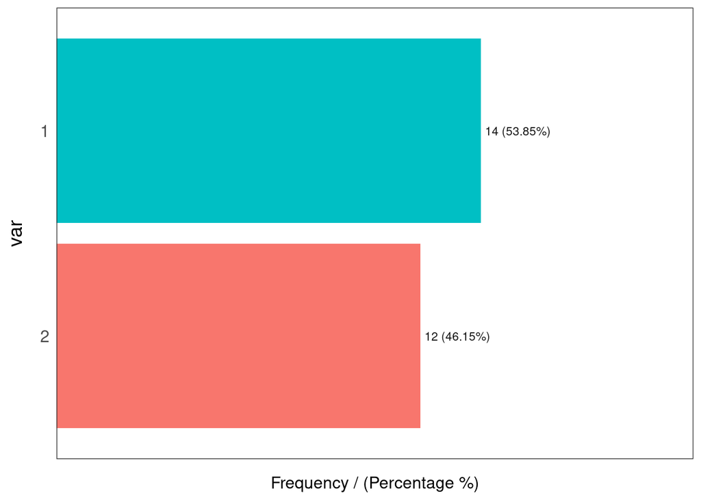

```
##   var frequency percentage cumulative_perc
## 1   1        14      53.85           53.85
## 2   2        12      46.15          100.00
```

```r
freq(surv_data$ecog.ps)
```

# 2. Survival anaysis

# 2.1. Linear models & Kaplan-Meier curves

Building initial linear model:

```r
km1 <- with(surv_data, Surv(futime,fustat))
km1_fit <- survfit(Surv(futime, fustat) ~ 1, data=surv_data)
summary(km1_fit, times = c(1,30,60,90*(1:10)))
```

```
## Call: survfit(formula = Surv(futime, fustat) ~ 1, data = surv_data)
##
##  time n.risk n.event survival std.err lower 95% CI upper 95% CI
##     1     26       0    1.000  0.0000        1.000        1.000
##    30     26       0    1.000  0.0000        1.000        1.000
##    60     25       1    0.962  0.0377        0.890        1.000
##    90     25       0    0.962  0.0377        0.890        1.000
##   180     23       2    0.885  0.0627        0.770        1.000
##   270     22       1    0.846  0.0708        0.718        0.997
##   360     20       2    0.769  0.0826        0.623        0.949
##   450     15       2    0.688  0.0919        0.529        0.894
##   540     12       2    0.596  0.0999        0.429        0.828
##   630     11       1    0.546  0.1032        0.377        0.791
##   720     10       1    0.497  0.1051        0.328        0.752
##   810      6       0    0.497  0.1051        0.328        0.752
##   900      5       0    0.497  0.1051        0.328        0.752
```

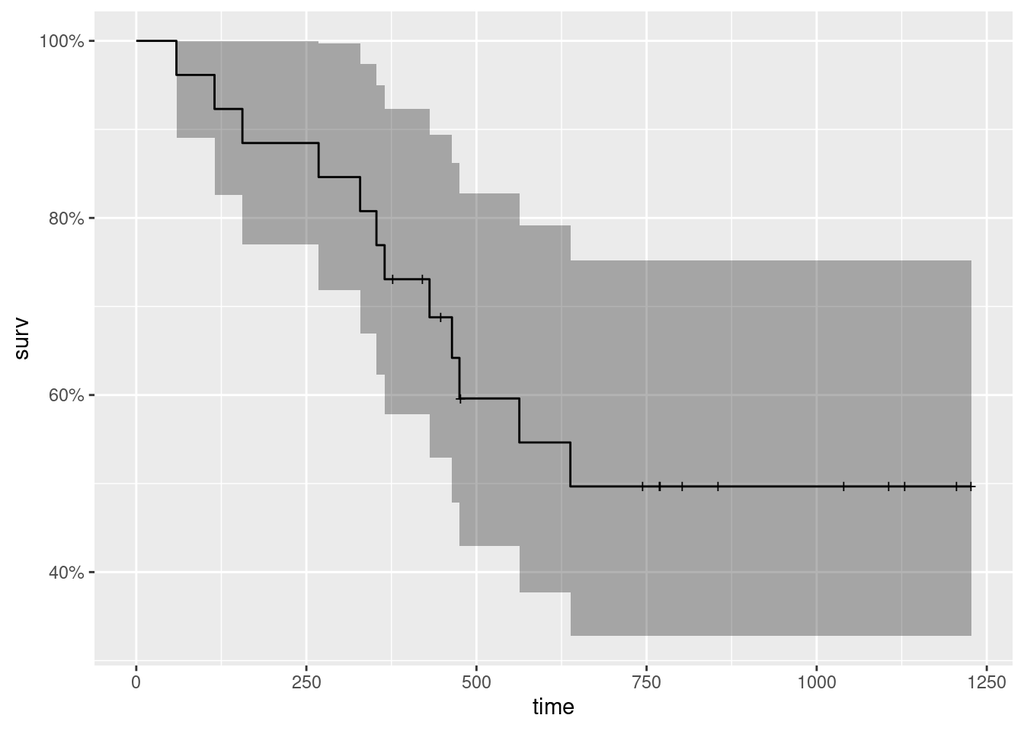

```r
autoplot(km1_fit)
```

How treatment type can impact on survival?

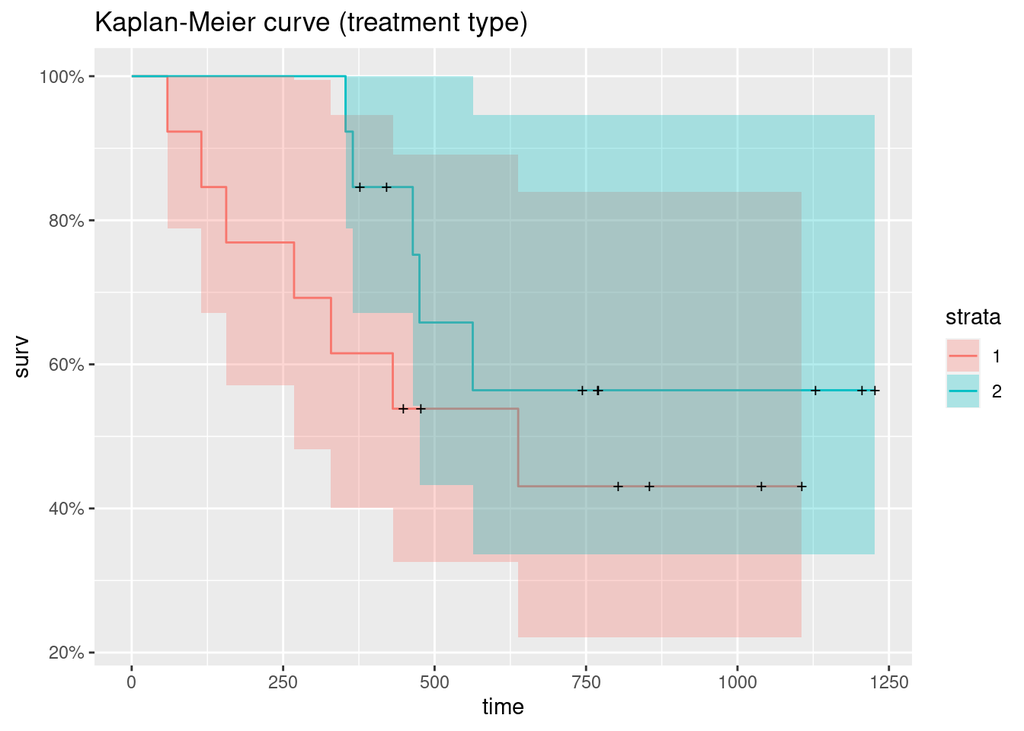

```r
km1_trt_fit <- survfit(Surv(futime, fustat) ~ rx, data=surv_data)
autoplot(km1_trt_fit, main = 'Kaplan-Meier curve (treatment type)')
```

Let’s transform our data to find any difference in survival between different groups. According to modern data, risks are significantly higher after age of 60 (63 to be exact). We transform *age* to factor with 2 grades: less than 60 years / over 60 years, as also changing some variables for more convenience:

```r
surv_data_mod <- mutate(surv_data, age_f = ifelse((age < 60), "LT60", "OV60"),
              age_f = factor(age_f),
              rx = factor(rx,labels=c("standard","test")),
              resid.ds = factor(resid.ds,labels=c("No","Yes")),
              ecog.ps = factor(ecog.ps,labels=c('Grade 1','Grade 2')))
```

First, let’s evaluate impact of age:

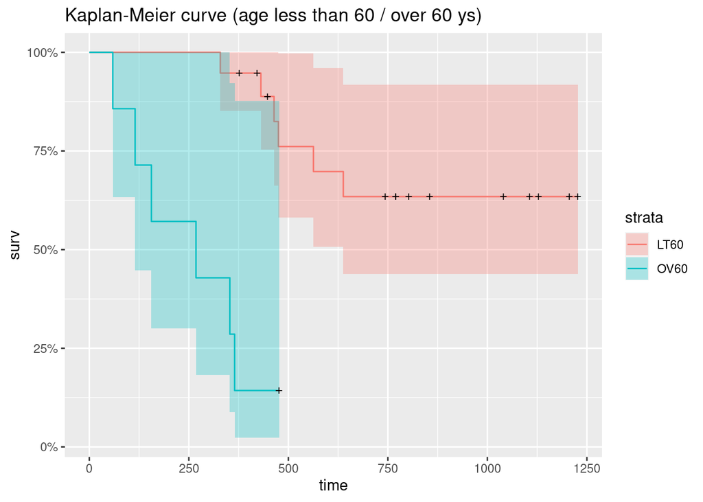

```r
km1_age_fit <- survfit(Surv(futime, fustat) ~ age_f, data=surv_data_mod)
autoplot(km1_age_fit, main = 'Kaplan-Meier curve (age less than 60 / over 60 ys)')
```

If patient over 60 ys old has ovarian cancer….well, you screwed. Now, residual diseases:

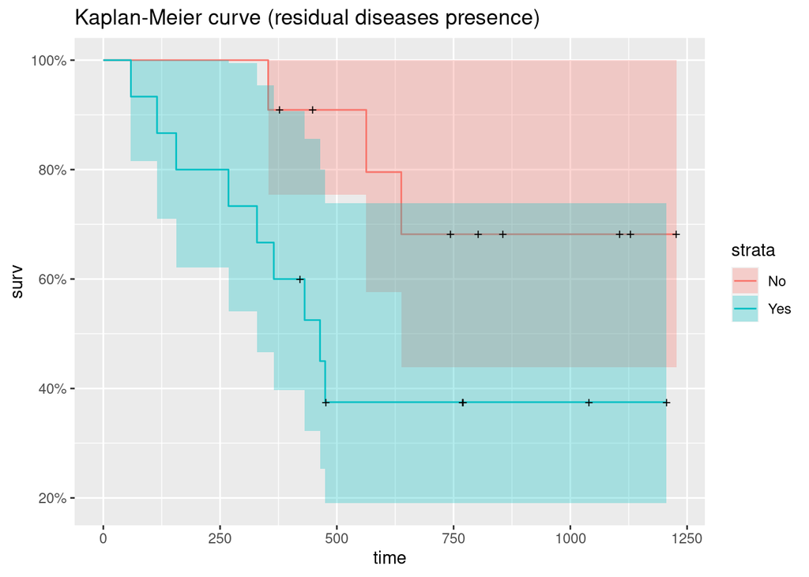

```r
km1_resid_fit <- survfit(Surv(futime, fustat) ~ resid.ds, data=surv_data_mod)
autoplot(km1_resid_fit, main = 'Kaplan-Meier curve (residual diseases presence)')
```

The more diseases you have, the less chances you have. Sad but true.

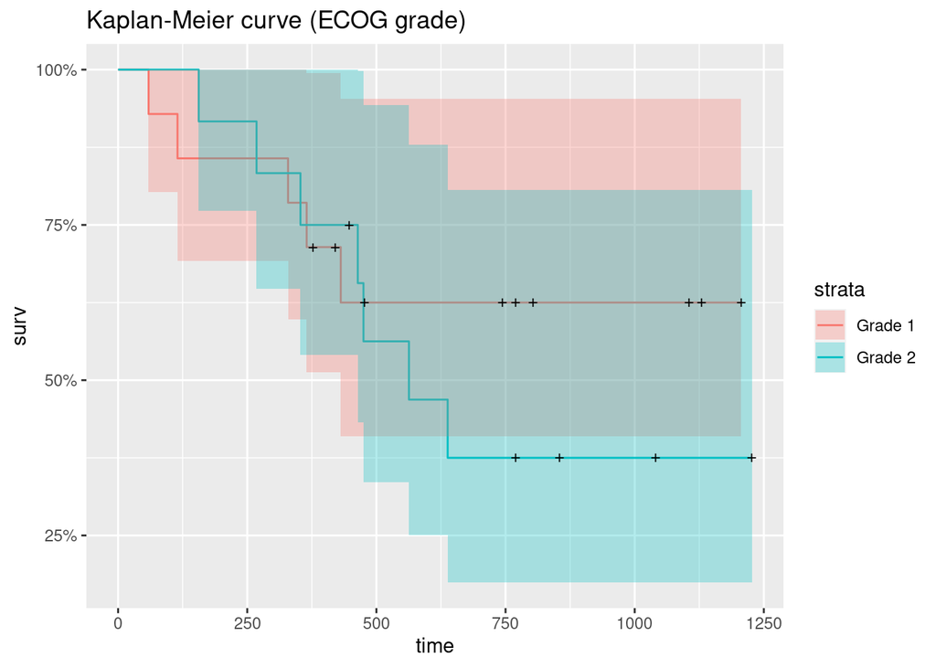

```r
km1_ecog_fit <- survfit(Surv(futime, fustat) ~ ecog.ps, data=surv_data_mod)
autoplot(km1_ecog_fit, main = 'Kaplan-Meier curve (ECOG grade)')
```

Can we estimate 2 factors at once? Yes, we can.

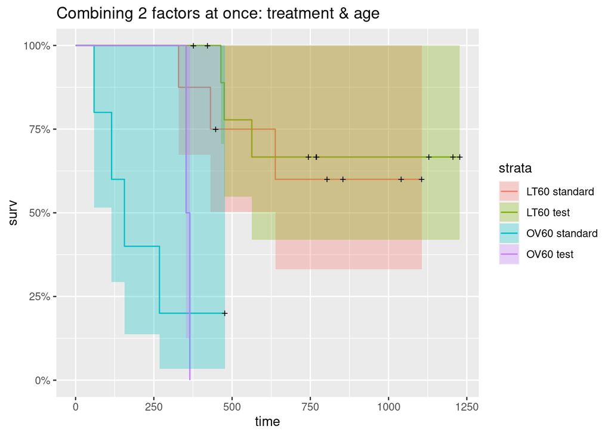

```r
surv_data_mod$hyb_age_rx <- paste(surv_data_mod$age_f, surv_data_mod$rx)
km1_trt_age_fit <- survfit(Surv(futime, fustat) ~ hyb_age_rx, data=surv_data_mod)
autoplot(km1_trt_age_fit, main='Combining 2 factors at once: treatment & age')
```

# 2.2. Log-rank test

Another method to estimate difference between groups is log-rank test.

```r
survdiff(Surv(futime, fustat) ~ rx, data = surv_data_mod)
```

```
## Call:
## survdiff(formula = Surv(futime, fustat) ~ rx, data = surv_data_mod)
##
##              N Observed Expected (O-E)^2/E (O-E)^2/V
## rx=standard 13        7     5.23     0.596      1.06
## rx=test     13        5     6.77     0.461      1.06
##
##  Chisq= 1.1  on 1 degrees of freedom, p= 0.3
```

```r
survdiff(Surv(futime, fustat) ~ age, data = surv_data_mod)
```

```
## Call:
## survdiff(formula = Surv(futime, fustat) ~ age, data = surv_data_mod)
##
##             N Observed Expected (O-E)^2/E (O-E)^2/V
## age=38.8932 1        0   0.6778     0.678     0.722
## age=39.2712 1        0   0.6778     0.678     0.722
## age=43.1233 1        0   0.6778     0.678     0.722
## age=43.137  1        1   0.2091     2.992     3.123
## age=44.2055 1        0   0.6778     0.678     0.722
## age=44.6    1        0   0.6778     0.678     0.722
## age=50.1096 1        0   0.6778     0.678     0.722
## age=50.3397 1        1   0.3655     1.101     1.155
## age=53.3644 1        0   0.3067     0.307     0.321
## age=53.9068 1        0   0.6778     0.678     0.722
## age=55.1781 1        1   0.5869     0.291     0.308
## age=56.4301 1        0   0.3655     0.366     0.383
## age=56.7562 1        1   0.6778     0.153     0.163
## age=56.937  1        1   0.4322     0.746     0.785
## age=57.0521 1        0   0.6778     0.678     0.722
## age=58.3096 1        0   0.3067     0.307     0.321
## age=59.589  1        0   0.6778     0.678     0.722
## age=59.6301 1        0   0.6778     0.678     0.722
## age=59.8548 1        1   0.5036     0.489     0.517
## age=63.2192 1        1   0.2567     2.153     2.249
## age=64.1753 1        0   0.5036     0.504     0.532
## age=64.4247 1        1   0.3067     1.567     1.640
## age=66.4658 1        1   0.1201     6.445     6.714
## age=72.3315 1        1   0.0385    24.038    25.000
## age=74.4932 1        1   0.0785    10.824    11.266
## age=74.5041 1        1   0.1636     4.276     4.459
##
##  Chisq= 71.9  on 25 degrees of freedom, p= 2e-06
```

```r
survdiff(Surv(futime, fustat) ~ resid.ds, data = surv_data_mod)
```

```
## Call:
## survdiff(formula = Surv(futime, fustat) ~ resid.ds, data = surv_data_mod)
##
##               N Observed Expected (O-E)^2/E (O-E)^2/V
## resid.ds=No  11        3     6.26      1.70      3.62
## resid.ds=Yes 15        9     5.74      1.85      3.62
##
##  Chisq= 3.6  on 1 degrees of freedom, p= 0.06
```

```r
survdiff(Surv(futime, fustat) ~ ecog.ps, data = surv_data_mod)
```

```
## Call:
## survdiff(formula = Surv(futime, fustat) ~ ecog.ps, data = surv_data_mod)
##
##                  N Observed Expected (O-E)^2/E (O-E)^2/V
## ecog.ps=Grade 1 14        5     6.18     0.226     0.468
## ecog.ps=Grade 2 12        7     5.82     0.240     0.468
##
##  Chisq= 0.5  on 1 degrees of freedom, p= 0.5
```

```r
logrank_test(Surv(futime, fustat) ~ rx,data=surv_data_mod)
```

```
##
##  Asymptotic Two-Sample Logrank Test
##
## data:  Surv(futime, fustat) by rx (standard, test)
## Z = -1.0296, p-value = 0.3032
## alternative hypothesis: true theta is not equal to 1
```

```r
logrank_test(Surv(futime, fustat) ~ age_f,data=surv_data_mod)
```

```
##
##  Asymptotic Two-Sample Logrank Test
##
## data:  Surv(futime, fustat) by age_f (LT60, OV60)
## Z = 2.9778, p-value = 0.002903
## alternative hypothesis: true theta is not equal to 1
```

```r
logrank_test(Surv(futime, fustat) ~ resid.ds,data=surv_data_mod)
```

```
##
##  Asymptotic Two-Sample Logrank Test
##
## data:  Surv(futime, fustat) by resid.ds (No, Yes)
## Z = 1.9234, p-value = 0.05444
## alternative hypothesis: true theta is not equal to 1
```

```r
logrank_test(Surv(futime, fustat) ~ ecog.ps,data=surv_data_mod)
```

```
##
##  Asymptotic Two-Sample Logrank Test
##
## data:  Surv(futime, fustat) by ecog.ps (Grade 1, Grade 2)
## Z = 0.69106, p-value = 0.4895
## alternative hypothesis: true theta is not equal to 1
```

To put in simple, the older patient is, the chances are significantly lower.

# 2.3. Cox model to analyse risk-impact factors

```r
cox <- coxph(Surv(futime, fustat) ~ rx + age + resid.ds + ecog.ps, data = surv_data)
summary(cox)
```

```
## Call:
## coxph(formula = Surv(futime, fustat) ~ rx + age + resid.ds +
##     ecog.ps, data = surv_data)
##
##   n= 26, number of events= 12
##
##              coef exp(coef) se(coef)      z Pr(>|z|)
## rx       -0.91450   0.40072  0.65332 -1.400  0.16158
## age       0.12481   1.13294  0.04689  2.662  0.00777 **
## resid.ds  0.82619   2.28459  0.78961  1.046  0.29541
## ecog.ps   0.33621   1.39964  0.64392  0.522  0.60158
## ---
## Signif. codes:  0 '***' 0.001 '**' 0.01 '*' 0.05 '.' 0.1 ' ' 1
##
##          exp(coef) exp(-coef) lower .95 upper .95
## rx          0.4007     2.4955    0.1114     1.442
## age         1.1329     0.8827    1.0335     1.242
## resid.ds    2.2846     0.4377    0.4861    10.738
## ecog.ps     1.3996     0.7145    0.3962     4.945
##
## Concordance= 0.807  (se = 0.068 )
## Likelihood ratio test= 17.04  on 4 df,   p=0.002
## Wald test            = 14.25  on 4 df,   p=0.007
## Score (logrank) test = 20.81  on 4 df,   p=3e-04
```

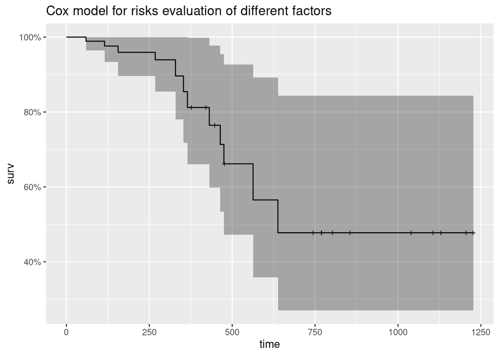

```r
cox_fit <- survfit(cox)
autoplot(cox_fit, main = 'Cox model for risks evaluation of different factors')
```

Covariates test:

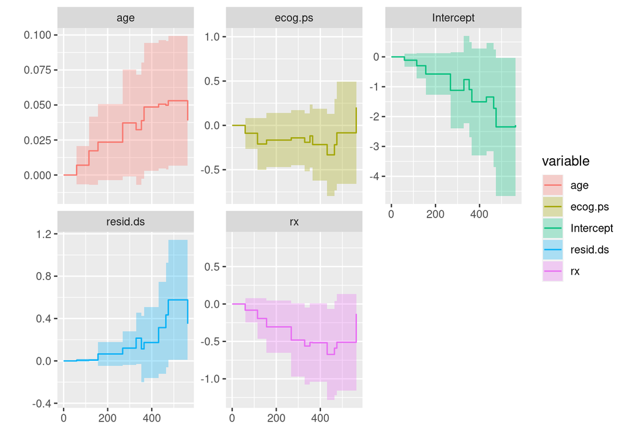

```r
aa_fit <- aareg(Surv(futime, fustat) ~ rx + age + resid.ds + ecog.ps, data = surv_data)
autoplot(aa_fit)
```

Hazard ratio analysis:

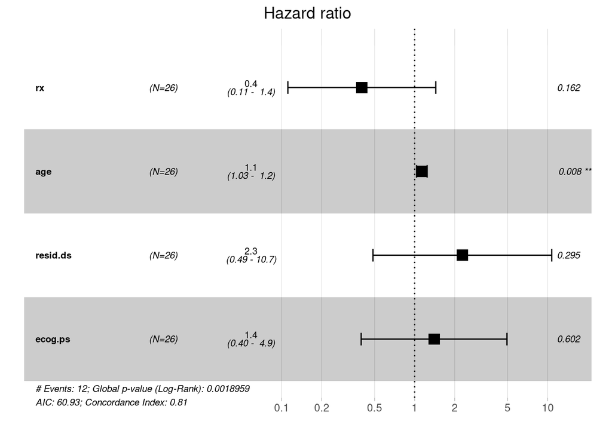

```r
fit.coxph <- coxph(Surv(futime, fustat) ~ rx + age + resid.ds + ecog.ps, data = surv_data)
ggforest(fit.coxph, data = surv_data)
```

# 2.4 Random forest model

This type of survival analysis allow to tack each patients’ fate.

```r
r_fit <- ranger(Surv(futime, fustat) ~ rx + age + resid.ds + ecog.ps, data = surv_data,
                mtry = 4,
                importance = "permutation",
                splitrule = "extratrees",
                verbose = TRUE)
```

```r
death_times <- r_fit$unique.death.times
surv_prob <- data.frame(r_fit$survival)
avg_prob <- sapply(surv_prob,mean)
```

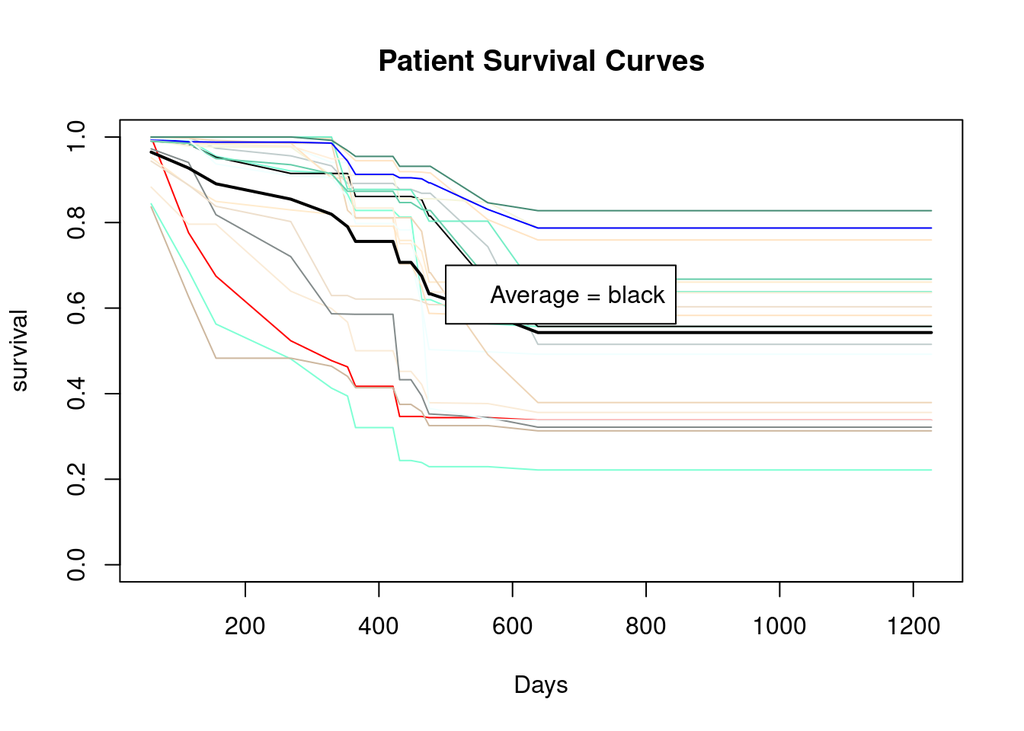

```r
plot(r_fit$unique.death.times,r_fit$survival[1,],
     type = "l",
     ylim = c(0,1),
     col = "red",
     xlab = "Days",
     ylab = "survival",
     main = "Patient Survival Curves")
cols <- colors()
for (n in sample(c(2:dim(surv_data)[1]), 20)){
  lines(r_fit$unique.death.times, r_fit$survival[n,], type = "l", col = cols[n])
}
lines(death_times, avg_prob, lwd = 2)
legend(500, 0.7, legend = c('Average = black'))
```

# 2.5. All 3 models alltogether

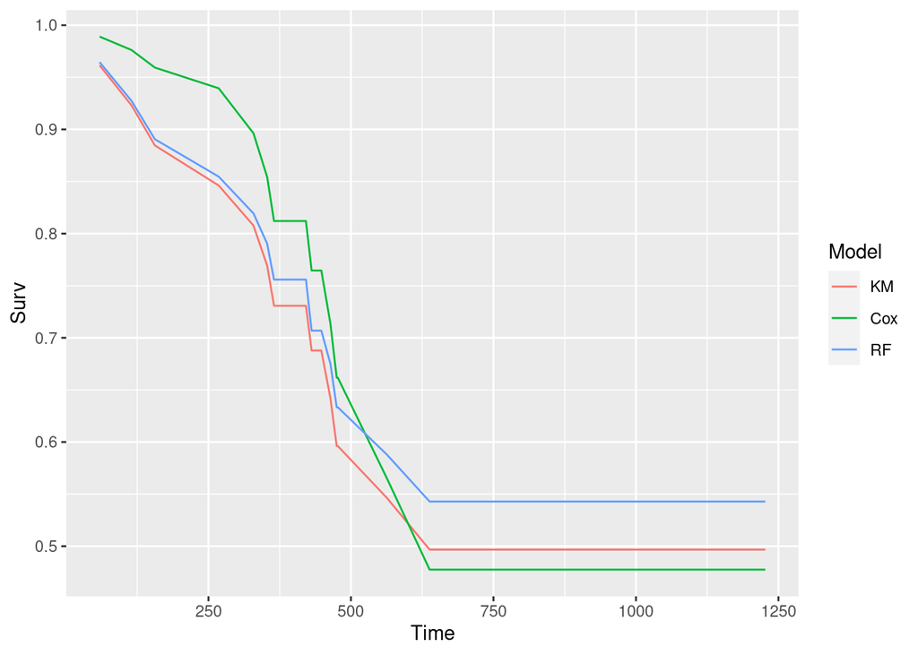

```r
kmi <- rep("KM",length(km1_fit$time))
km_df <- data.frame(km1_fit$time,km1_fit$surv,kmi)
names(km_df) <- c("Time","Surv","Model")

coxi <- rep("Cox",length(cox_fit$time))
cox_df <- data.frame(cox_fit$time,cox_fit$surv,coxi)
names(cox_df) <- c("Time","Surv","Model")

rfi <- rep("RF",length(r_fit$unique.death.times))
rf_df <- data.frame(r_fit$unique.death.times,avg_prob,rfi)
names(rf_df) <- c("Time","Surv","Model")

plot_df <- rbind(km_df,cox_df,rf_df)

p <- ggplot(plot_df, aes(x = Time, y = Surv, color = Model))
p + geom_line()
```

Thank you for your attention!